# Risk Factor Analysis

## Outcome Variable

**Outcome Variable:** haz

## Predictor Variables

**Intervention Variable:** vagbrth

**Adjustment Set:**

- arm
- sex
- W_mage
- meducyrs
- feducyrs
- hhwealth_quart
- W_mhtcm
- W_mwtkg
- W_mbmi
- single
- W_nrooms
- brthmon
- W_parity
- impfloor
- delta_W_mage
- delta_meducyrs
- delta_feducyrs
- delta_hhwealth_quart
- delta_W_mhtcm
- delta_W_mwtkg
- delta_W_mbmi
- delta_single
- delta_W_nrooms
- delta_brthmon
- delta_W_parity
- delta_impfloor

## Stratifying Variables

The analysis was stratified on these variable(s):

- agecat
- studyid
- country

## Data Summary

| agecat | studyid | country | vagbrth | n_cell | n | outcome_variable |
| --- | --- | --- | --- | --- | --- | --- |
| Birth | ki1000108-CMC-V-BCS-2002 | INDIA | 0 | 11 | 92 | haz |
| Birth | ki1000108-CMC-V-BCS-2002 | INDIA | 1 | 81 | 92 | haz |
| Birth | ki1000108-IRC | INDIA | 0 | 68 | 388 | haz |
| Birth | ki1000108-IRC | INDIA | 1 | 320 | 388 | haz |
| Birth | ki1017093b-PROVIDE | BANGLADESH | 0 | 108 | 539 | haz |
| Birth | ki1017093b-PROVIDE | BANGLADESH | 1 | 431 | 539 | haz |
| Birth | ki1017093c-NIH-Crypto | BANGLADESH | 0 | 186 | 477 | haz |
| Birth | ki1017093c-NIH-Crypto | BANGLADESH | 1 | 291 | 477 | haz |
| Birth | ki1119695-PROBIT | BELARUS | 0 | 1597 | 13890 | haz |
| Birth | ki1119695-PROBIT | BELARUS | 1 | 12293 | 13890 | haz |
| Birth | ki1126311-ZVITAMBO | ZIMBABWE | 0 | 1166 | 13761 | haz |
| Birth | ki1126311-ZVITAMBO | ZIMBABWE | 1 | 12595 | 13761 | haz |
| Birth | kiGH5241-JiVitA-3 | BANGLADESH | 0 | 539 | 22418 | haz |
| Birth | kiGH5241-JiVitA-3 | BANGLADESH | 1 | 21879 | 22418 | haz |
| Birth | kiGH5241-JiVitA-4 | BANGLADESH | 0 | 76 | 2822 | haz |
| Birth | kiGH5241-JiVitA-4 | BANGLADESH | 1 | 2746 | 2822 | haz |
| 6 months | ki1000108-CMC-V-BCS-2002 | INDIA | 0 | 25 | 369 | haz |
| 6 months | ki1000108-CMC-V-BCS-2002 | INDIA | 1 | 344 | 369 | haz |
| 6 months | ki1000108-IRC | INDIA | 0 | 69 | 407 | haz |
| 6 months | ki1000108-IRC | INDIA | 1 | 338 | 407 | haz |
| 6 months | ki1017093b-PROVIDE | BANGLADESH | 0 | 139 | 604 | haz |
| 6 months | ki1017093b-PROVIDE | BANGLADESH | 1 | 465 | 604 | haz |
| 6 months | ki1017093c-NIH-Crypto | BANGLADESH | 0 | 187 | 457 | haz |
| 6 months | ki1017093c-NIH-Crypto | BANGLADESH | 1 | 270 | 457 | haz |
| 6 months | ki1066203-TanzaniaChild2 | TANZANIA, UNITED REPUBLIC OF | 0 | 189 | 2005 | haz |
| 6 months | ki1066203-TanzaniaChild2 | TANZANIA, UNITED REPUBLIC OF | 1 | 1816 | 2005 | haz |
| 6 months | ki1119695-PROBIT | BELARUS | 0 | 1799 | 15761 | haz |
| 6 months | ki1119695-PROBIT | BELARUS | 1 | 13962 | 15761 | haz |
| 6 months | ki1126311-ZVITAMBO | ZIMBABWE | 0 | 740 | 8601 | haz |
| 6 months | ki1126311-ZVITAMBO | ZIMBABWE | 1 | 7861 | 8601 | haz |
| 6 months | kiGH5241-JiVitA-3 | BANGLADESH | 0 | 1077 | 16732 | haz |
| 6 months | kiGH5241-JiVitA-3 | BANGLADESH | 1 | 15655 | 16732 | haz |
| 6 months | kiGH5241-JiVitA-4 | BANGLADESH | 0 | 336 | 4052 | haz |
| 6 months | kiGH5241-JiVitA-4 | BANGLADESH | 1 | 3716 | 4052 | haz |
| 24 months | ki1000108-CMC-V-BCS-2002 | INDIA | 0 | 24 | 371 | haz |
| 24 months | ki1000108-CMC-V-BCS-2002 | INDIA | 1 | 347 | 371 | haz |
| 24 months | ki1000108-IRC | INDIA | 0 | 69 | 409 | haz |
| 24 months | ki1000108-IRC | INDIA | 1 | 340 | 409 | haz |
| 24 months | ki1017093b-PROVIDE | BANGLADESH | 0 | 137 | 578 | haz |
| 24 months | ki1017093b-PROVIDE | BANGLADESH | 1 | 441 | 578 | haz |
| 24 months | ki1017093c-NIH-Crypto | BANGLADESH | 0 | 99 | 260 | haz |
| 24 months | ki1017093c-NIH-Crypto | BANGLADESH | 1 | 161 | 260 | haz |
| 24 months | ki1066203-TanzaniaChild2 | TANZANIA, UNITED REPUBLIC OF | 0 | 2 | 6 | haz |
| 24 months | ki1066203-TanzaniaChild2 | TANZANIA, UNITED REPUBLIC OF | 1 | 4 | 6 | haz |
| 24 months | ki1119695-PROBIT | BELARUS | 0 | 472 | 4035 | haz |
| 24 months | ki1119695-PROBIT | BELARUS | 1 | 3563 | 4035 | haz |
| 24 months | ki1126311-ZVITAMBO | ZIMBABWE | 0 | 133 | 1619 | haz |
| 24 months | ki1126311-ZVITAMBO | ZIMBABWE | 1 | 1486 | 1619 | haz |
| 24 months | kiGH5241-JiVitA-3 | BANGLADESH | 0 | 480 | 8584 | haz |
| 24 months | kiGH5241-JiVitA-3 | BANGLADESH | 1 | 8104 | 8584 | haz |
| 24 months | kiGH5241-JiVitA-4 | BANGLADESH | 0 | 323 | 4020 | haz |
| 24 months | kiGH5241-JiVitA-4 | BANGLADESH | 1 | 3697 | 4020 | haz |

The following strata were considered:

- agecat: 24 months, studyid: ki1000108-CMC-V-BCS-2002, country: INDIA
- agecat: 24 months, studyid: ki1000108-IRC, country: INDIA
- agecat: 24 months, studyid: ki1017093b-PROVIDE, country: BANGLADESH
- agecat: 24 months, studyid: ki1017093c-NIH-Crypto, country: BANGLADESH
- agecat: 24 months, studyid: ki1066203-TanzaniaChild2, country: TANZANIA, UNITED REPUBLIC OF
- agecat: 24 months, studyid: ki1119695-PROBIT, country: BELARUS
- agecat: 24 months, studyid: ki1126311-ZVITAMBO, country: ZIMBABWE
- agecat: 24 months, studyid: kiGH5241-JiVitA-3, country: BANGLADESH
- agecat: 24 months, studyid: kiGH5241-JiVitA-4, country: BANGLADESH
- agecat: 6 months, studyid: ki1000108-CMC-V-BCS-2002, country: INDIA
- agecat: 6 months, studyid: ki1000108-IRC, country: INDIA
- agecat: 6 months, studyid: ki1017093b-PROVIDE, country: BANGLADESH
- agecat: 6 months, studyid: ki1017093c-NIH-Crypto, country: BANGLADESH
- agecat: 6 months, studyid: ki1066203-TanzaniaChild2, country: TANZANIA, UNITED REPUBLIC OF
- agecat: 6 months, studyid: ki1119695-PROBIT, country: BELARUS
- agecat: 6 months, studyid: ki1126311-ZVITAMBO, country: ZIMBABWE
- agecat: 6 months, studyid: kiGH5241-JiVitA-3, country: BANGLADESH
- agecat: 6 months, studyid: kiGH5241-JiVitA-4, country: BANGLADESH
- agecat: Birth, studyid: ki1000108-CMC-V-BCS-2002, country: INDIA
- agecat: Birth, studyid: ki1000108-IRC, country: INDIA
- agecat: Birth, studyid: ki1017093b-PROVIDE, country: BANGLADESH
- agecat: Birth, studyid: ki1017093c-NIH-Crypto, country: BANGLADESH
- agecat: Birth, studyid: ki1119695-PROBIT, country: BELARUS
- agecat: Birth, studyid: ki1126311-ZVITAMBO, country: ZIMBABWE
- agecat: Birth, studyid: kiGH5241-JiVitA-3, country: BANGLADESH
- agecat: Birth, studyid: kiGH5241-JiVitA-4, country: BANGLADESH

### Dropped Strata

Some strata were dropped due to rare outcomes:

- agecat: 24 months, studyid: ki1066203-TanzaniaChild2, country: TANZANIA, UNITED REPUBLIC OF

## Methods Detail

We’re interested in the causal parameters $E[Y_a]$ for all values of $a \in \mathcal{A}$. These parameters represent the mean outcome if, possibly contrary to fact, we intervened to set all units to have $A=a$. Under the randomization and positivity assumptions, these are identified by the statistical parameters $\psi_a=E_W[E_{Y|A,W}(Y|A=a,W)]$. In addition, we’re interested in the mean of $Y$, $E[Y]$ under no intervention (the observed mean). We will estimate these parameters by using SuperLearner to fit the relevant likelihood factors – $E_{Y|A,W}(Y|A=a,W)$ and $p(A=a|W)$, and then updating our likelihood fit using a joint TMLE.

For unadjusted analyses ($W=\{\}$), initial likelihoods were estimated using Lrnr_glm to estimate the simple $E(Y|A)$ and Lrnr_mean to estimate $p(A)$. For adjusted analyses, a small library containing Lrnr_glmnet, Lrnr_xgboost, and Lrnr_mean was used.

Having estimated these parameters, we will then use the delta method to estimate relative risks and attributable risks relative to a prespecified baseline level of $A$.

# Results Detail

## Results Plots

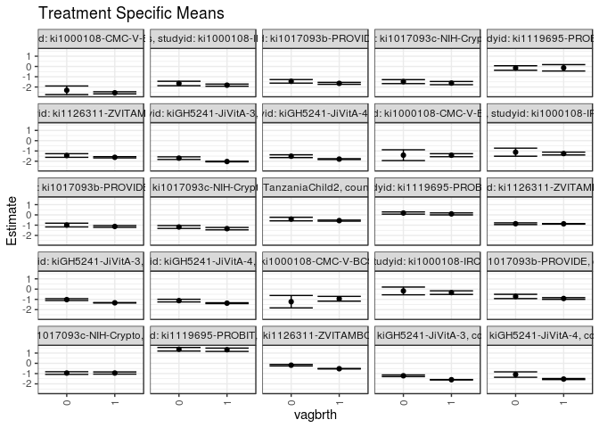

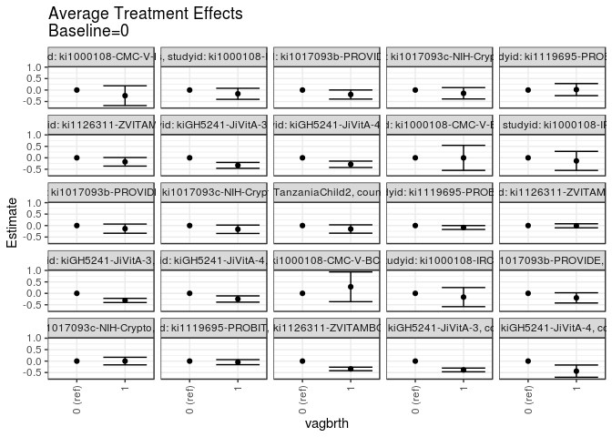

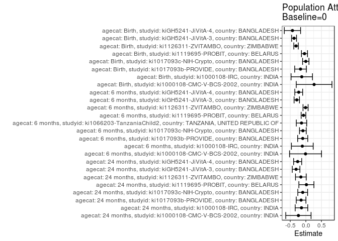

## Results Table

### Parameter: TSM

| agecat | studyid | country | intervention_level | baseline_level | estimate | ci_lower | ci_upper |
| --- | --- | --- | --- | --- | --- | --- | --- |
| Birth | ki1000108-CMC-V-BCS-2002 | INDIA | 0 | NA | -1.2258304 | -1.8312705 | -0.6203902 |
| Birth | ki1000108-CMC-V-BCS-2002 | INDIA | 1 | NA | -0.9403800 | -1.1724750 | -0.7082850 |
| Birth | ki1000108-IRC | INDIA | 0 | NA | -0.1773636 | -0.5551861 | 0.2004590 |
| Birth | ki1000108-IRC | INDIA | 1 | NA | -0.3421731 | -0.5183199 | -0.1660264 |
| Birth | ki1017093b-PROVIDE | BANGLADESH | 0 | NA | -0.7150542 | -0.9231432 | -0.5069653 |
| Birth | ki1017093b-PROVIDE | BANGLADESH | 1 | NA | -0.9130320 | -0.9946776 | -0.8313864 |
| Birth | ki1017093c-NIH-Crypto | BANGLADESH | 0 | NA | -0.9463913 | -1.0743790 | -0.8184035 |
| Birth | ki1017093c-NIH-Crypto | BANGLADESH | 1 | NA | -0.9454335 | -1.0517255 | -0.8391414 |
| Birth | ki1119695-PROBIT | BELARUS | 0 | NA | 1.3703855 | 1.1960804 | 1.5446905 |
| Birth | ki1119695-PROBIT | BELARUS | 1 | NA | 1.3235351 | 1.1628252 | 1.4842451 |
| Birth | ki1126311-ZVITAMBO | ZIMBABWE | 0 | NA | -0.1833738 | -0.2578261 | -0.1089215 |
| Birth | ki1126311-ZVITAMBO | ZIMBABWE | 1 | NA | -0.5262508 | -0.5477956 | -0.5047060 |
| Birth | kiGH5241-JiVitA-3 | BANGLADESH | 0 | NA | -1.2122397 | -1.2923640 | -1.1321153 |
| Birth | kiGH5241-JiVitA-3 | BANGLADESH | 1 | NA | -1.5982246 | -1.6177242 | -1.5787250 |
| Birth | kiGH5241-JiVitA-4 | BANGLADESH | 0 | NA | -1.0940469 | -1.3570466 | -0.8310472 |
| Birth | kiGH5241-JiVitA-4 | BANGLADESH | 1 | NA | -1.5326691 | -1.5826951 | -1.4826431 |
| 6 months | ki1000108-CMC-V-BCS-2002 | INDIA | 0 | NA | -1.4133974 | -1.9389764 | -0.8878185 |
| 6 months | ki1000108-CMC-V-BCS-2002 | INDIA | 1 | NA | -1.4152700 | -1.5625561 | -1.2679839 |
| 6 months | ki1000108-IRC | INDIA | 0 | NA | -1.1210894 | -1.5138393 | -0.7283395 |
| 6 months | ki1000108-IRC | INDIA | 1 | NA | -1.2554808 | -1.3923694 | -1.1185922 |
| 6 months | ki1017093b-PROVIDE | BANGLADESH | 0 | NA | -0.9913511 | -1.1733812 | -0.8093211 |
| 6 months | ki1017093b-PROVIDE | BANGLADESH | 1 | NA | -1.1259780 | -1.2112493 | -1.0407067 |
| 6 months | ki1017093c-NIH-Crypto | BANGLADESH | 0 | NA | -1.1784825 | -1.3192841 | -1.0376809 |
| 6 months | ki1017093c-NIH-Crypto | BANGLADESH | 1 | NA | -1.3400555 | -1.4562170 | -1.2238939 |
| 6 months | ki1066203-TanzaniaChild2 | TANZANIA, UNITED REPUBLIC OF | 0 | NA | -0.4066462 | -0.5816543 | -0.2316381 |
| 6 months | ki1066203-TanzaniaChild2 | TANZANIA, UNITED REPUBLIC OF | 1 | NA | -0.5571596 | -0.6088491 | -0.5054700 |
| 6 months | ki1119695-PROBIT | BELARUS | 0 | NA | 0.1824785 | 0.0738966 | 0.2910605 |
| 6 months | ki1119695-PROBIT | BELARUS | 1 | NA | 0.0970055 | 0.0002425 | 0.1937685 |
| 6 months | ki1126311-ZVITAMBO | ZIMBABWE | 0 | NA | -0.8596598 | -0.9443405 | -0.7749790 |
| 6 months | ki1126311-ZVITAMBO | ZIMBABWE | 1 | NA | -0.8695664 | -0.8965303 | -0.8426025 |
| 6 months | kiGH5241-JiVitA-3 | BANGLADESH | 0 | NA | -1.0229693 | -1.1127649 | -0.9331738 |
| 6 months | kiGH5241-JiVitA-3 | BANGLADESH | 1 | NA | -1.3333478 | -1.3564323 | -1.3102632 |
| 6 months | kiGH5241-JiVitA-4 | BANGLADESH | 0 | NA | -1.1220927 | -1.2527851 | -0.9914003 |
| 6 months | kiGH5241-JiVitA-4 | BANGLADESH | 1 | NA | -1.3699323 | -1.4136657 | -1.3261989 |
| 24 months | ki1000108-CMC-V-BCS-2002 | INDIA | 0 | NA | -2.3208440 | -2.7400717 | -1.9016162 |
| 24 months | ki1000108-CMC-V-BCS-2002 | INDIA | 1 | NA | -2.5671280 | -2.6699030 | -2.4643530 |
| 24 months | ki1000108-IRC | INDIA | 0 | NA | -1.6590417 | -1.8765669 | -1.4415164 |
| 24 months | ki1000108-IRC | INDIA | 1 | NA | -1.8230162 | -1.9263402 | -1.7196923 |
| 24 months | ki1017093b-PROVIDE | BANGLADESH | 0 | NA | -1.4502642 | -1.6251223 | -1.2754060 |
| 24 months | ki1017093b-PROVIDE | BANGLADESH | 1 | NA | -1.6460853 | -1.7410876 | -1.5510831 |
| 24 months | ki1017093c-NIH-Crypto | BANGLADESH | 0 | NA | -1.4774484 | -1.6693007 | -1.2855962 |
| 24 months | ki1017093c-NIH-Crypto | BANGLADESH | 1 | NA | -1.6197880 | -1.7762062 | -1.4633698 |
| 24 months | ki1119695-PROBIT | BELARUS | 0 | NA | -0.1497530 | -0.3702492 | 0.0707432 |
| 24 months | ki1119695-PROBIT | BELARUS | 1 | NA | -0.1310341 | -0.4421501 | 0.1800820 |
| 24 months | ki1126311-ZVITAMBO | ZIMBABWE | 0 | NA | -1.4451449 | -1.6234138 | -1.2668760 |
| 24 months | ki1126311-ZVITAMBO | ZIMBABWE | 1 | NA | -1.6203301 | -1.6804571 | -1.5602031 |
| 24 months | kiGH5241-JiVitA-3 | BANGLADESH | 0 | NA | -1.7017922 | -1.8295744 | -1.5740101 |
| 24 months | kiGH5241-JiVitA-3 | BANGLADESH | 1 | NA | -2.0312178 | -2.0586882 | -2.0037475 |
| 24 months | kiGH5241-JiVitA-4 | BANGLADESH | 0 | NA | -1.5113104 | -1.6473634 | -1.3752573 |
| 24 months | kiGH5241-JiVitA-4 | BANGLADESH | 1 | NA | -1.7945821 | -1.8338909 | -1.7552733 |

### Parameter: E(Y)

| agecat | studyid | country | intervention_level | baseline_level | estimate | ci_lower | ci_upper |
| --- | --- | --- | --- | --- | --- | --- | --- |
| Birth | ki1000108-CMC-V-BCS-2002 | INDIA | NA | NA | -0.9611957 | -1.1776967 | -0.7446946 |
| Birth | ki1000108-IRC | INDIA | NA | NA | -0.3080412 | -0.4687931 | -0.1472894 |
| Birth | ki1017093b-PROVIDE | BANGLADESH | NA | NA | -0.8851020 | -0.9601332 | -0.8100709 |
| Birth | ki1017093c-NIH-Crypto | BANGLADESH | NA | NA | -0.9480084 | -1.0301396 | -0.8658772 |
| Birth | ki1119695-PROBIT | BELARUS | NA | NA | 1.3269446 | 1.1683850 | 1.4855041 |
| Birth | ki1126311-ZVITAMBO | ZIMBABWE | NA | NA | -0.4970772 | -0.5177022 | -0.4764523 |
| Birth | kiGH5241-JiVitA-3 | BANGLADESH | NA | NA | -1.5892417 | -1.6084834 | -1.5700000 |
| Birth | kiGH5241-JiVitA-4 | BANGLADESH | NA | NA | -1.5231680 | -1.5722488 | -1.4740872 |
| 6 months | ki1000108-CMC-V-BCS-2002 | INDIA | NA | NA | -1.4234508 | -1.5645974 | -1.2823042 |
| 6 months | ki1000108-IRC | INDIA | NA | NA | -1.2344062 | -1.3658524 | -1.1029600 |
| 6 months | ki1017093b-PROVIDE | BANGLADESH | NA | NA | -1.0916915 | -1.1661176 | -1.0172654 |
| 6 months | ki1017093c-NIH-Crypto | BANGLADESH | NA | NA | -1.2731619 | -1.3626957 | -1.1836282 |
| 6 months | ki1066203-TanzaniaChild2 | TANZANIA, UNITED REPUBLIC OF | NA | NA | -0.5455565 | -0.5948696 | -0.4962435 |
| 6 months | ki1119695-PROBIT | BELARUS | NA | NA | 0.1069986 | 0.0122286 | 0.2017686 |
| 6 months | ki1126311-ZVITAMBO | ZIMBABWE | NA | NA | -0.8685914 | -0.8942954 | -0.8428875 |
| 6 months | kiGH5241-JiVitA-3 | BANGLADESH | NA | NA | -1.3134013 | -1.3366073 | -1.2901952 |
| 6 months | kiGH5241-JiVitA-4 | BANGLADESH | NA | NA | -1.3500888 | -1.3921730 | -1.3080047 |
| 24 months | ki1000108-CMC-V-BCS-2002 | INDIA | NA | NA | -2.5588679 | -2.6583730 | -2.4593629 |
| 24 months | ki1000108-IRC | INDIA | NA | NA | -1.7987775 | -1.8923914 | -1.7051636 |
| 24 months | ki1017093b-PROVIDE | BANGLADESH | NA | NA | -1.6024221 | -1.6857420 | -1.5191023 |
| 24 months | ki1017093c-NIH-Crypto | BANGLADESH | NA | NA | -1.5776538 | -1.6988448 | -1.4564629 |
| 24 months | ki1119695-PROBIT | BELARUS | NA | NA | -0.1314048 | -0.4282725 | 0.1654630 |
| 24 months | ki1126311-ZVITAMBO | ZIMBABWE | NA | NA | -1.6043391 | -1.6616652 | -1.5470130 |
| 24 months | kiGH5241-JiVitA-3 | BANGLADESH | NA | NA | -2.0144245 | -2.0420946 | -1.9867544 |
| 24 months | kiGH5241-JiVitA-4 | BANGLADESH | NA | NA | -1.7734527 | -1.8119258 | -1.7349797 |

### Parameter: ATE

| agecat | studyid | country | intervention_level | baseline_level | estimate | ci_lower | ci_upper |
| --- | --- | --- | --- | --- | --- | --- | --- |
| Birth | ki1000108-CMC-V-BCS-2002 | INDIA | 0 | 0 | 0.0000000 | 0.0000000 | 0.0000000 |
| Birth | ki1000108-CMC-V-BCS-2002 | INDIA | 1 | 0 | 0.2854504 | -0.3641407 | 0.9350415 |
| Birth | ki1000108-IRC | INDIA | 0 | 0 | 0.0000000 | 0.0000000 | 0.0000000 |
| Birth | ki1000108-IRC | INDIA | 1 | 0 | -0.1648096 | -0.5821797 | 0.2525605 |
| Birth | ki1017093b-PROVIDE | BANGLADESH | 0 | 0 | 0.0000000 | 0.0000000 | 0.0000000 |
| Birth | ki1017093b-PROVIDE | BANGLADESH | 1 | 0 | -0.1979778 | -0.4211640 | 0.0252084 |
| Birth | ki1017093c-NIH-Crypto | BANGLADESH | 0 | 0 | 0.0000000 | 0.0000000 | 0.0000000 |
| Birth | ki1017093c-NIH-Crypto | BANGLADESH | 1 | 0 | 0.0009578 | -0.1653231 | 0.1672387 |
| Birth | ki1119695-PROBIT | BELARUS | 0 | 0 | 0.0000000 | 0.0000000 | 0.0000000 |
| Birth | ki1119695-PROBIT | BELARUS | 1 | 0 | -0.0468503 | -0.1567395 | 0.0630388 |
| Birth | ki1126311-ZVITAMBO | ZIMBABWE | 0 | 0 | 0.0000000 | 0.0000000 | 0.0000000 |
| Birth | ki1126311-ZVITAMBO | ZIMBABWE | 1 | 0 | -0.3428770 | -0.4203526 | -0.2654015 |
| Birth | kiGH5241-JiVitA-3 | BANGLADESH | 0 | 0 | 0.0000000 | 0.0000000 | 0.0000000 |
| Birth | kiGH5241-JiVitA-3 | BANGLADESH | 1 | 0 | -0.3859849 | -0.4670275 | -0.3049423 |
| Birth | kiGH5241-JiVitA-4 | BANGLADESH | 0 | 0 | 0.0000000 | 0.0000000 | 0.0000000 |
| Birth | kiGH5241-JiVitA-4 | BANGLADESH | 1 | 0 | -0.4386222 | -0.7063289 | -0.1709154 |
| 6 months | ki1000108-CMC-V-BCS-2002 | INDIA | 0 | 0 | 0.0000000 | 0.0000000 | 0.0000000 |
| 6 months | ki1000108-CMC-V-BCS-2002 | INDIA | 1 | 0 | -0.0018726 | -0.5479505 | 0.5442054 |
| 6 months | ki1000108-IRC | INDIA | 0 | 0 | 0.0000000 | 0.0000000 | 0.0000000 |
| 6 months | ki1000108-IRC | INDIA | 1 | 0 | -0.1343914 | -0.5491631 | 0.2803803 |
| 6 months | ki1017093b-PROVIDE | BANGLADESH | 0 | 0 | 0.0000000 | 0.0000000 | 0.0000000 |
| 6 months | ki1017093b-PROVIDE | BANGLADESH | 1 | 0 | -0.1346269 | -0.3355246 | 0.0662709 |
| 6 months | ki1017093c-NIH-Crypto | BANGLADESH | 0 | 0 | 0.0000000 | 0.0000000 | 0.0000000 |
| 6 months | ki1017093c-NIH-Crypto | BANGLADESH | 1 | 0 | -0.1615729 | -0.3442538 | 0.0211080 |
| 6 months | ki1066203-TanzaniaChild2 | TANZANIA, UNITED REPUBLIC OF | 0 | 0 | 0.0000000 | 0.0000000 | 0.0000000 |
| 6 months | ki1066203-TanzaniaChild2 | TANZANIA, UNITED REPUBLIC OF | 1 | 0 | -0.1505134 | -0.3321723 | 0.0311455 |
| 6 months | ki1119695-PROBIT | BELARUS | 0 | 0 | 0.0000000 | 0.0000000 | 0.0000000 |
| 6 months | ki1119695-PROBIT | BELARUS | 1 | 0 | -0.0854730 | -0.1703830 | -0.0005629 |
| 6 months | ki1126311-ZVITAMBO | ZIMBABWE | 0 | 0 | 0.0000000 | 0.0000000 | 0.0000000 |
| 6 months | ki1126311-ZVITAMBO | ZIMBABWE | 1 | 0 | -0.0099066 | -0.0983057 | 0.0784925 |
| 6 months | kiGH5241-JiVitA-3 | BANGLADESH | 0 | 0 | 0.0000000 | 0.0000000 | 0.0000000 |
| 6 months | kiGH5241-JiVitA-3 | BANGLADESH | 1 | 0 | -0.3103784 | -0.4013056 | -0.2194512 |
| 6 months | kiGH5241-JiVitA-4 | BANGLADESH | 0 | 0 | 0.0000000 | 0.0000000 | 0.0000000 |
| 6 months | kiGH5241-JiVitA-4 | BANGLADESH | 1 | 0 | -0.2478396 | -0.3843730 | -0.1113062 |
| 24 months | ki1000108-CMC-V-BCS-2002 | INDIA | 0 | 0 | 0.0000000 | 0.0000000 | 0.0000000 |
| 24 months | ki1000108-CMC-V-BCS-2002 | INDIA | 1 | 0 | -0.2462840 | -0.6777703 | 0.1852022 |
| 24 months | ki1000108-IRC | INDIA | 0 | 0 | 0.0000000 | 0.0000000 | 0.0000000 |
| 24 months | ki1000108-IRC | INDIA | 1 | 0 | -0.1639746 | -0.4054327 | 0.0774836 |
| 24 months | ki1017093b-PROVIDE | BANGLADESH | 0 | 0 | 0.0000000 | 0.0000000 | 0.0000000 |
| 24 months | ki1017093b-PROVIDE | BANGLADESH | 1 | 0 | -0.1958212 | -0.3948208 | 0.0031784 |
| 24 months | ki1017093c-NIH-Crypto | BANGLADESH | 0 | 0 | 0.0000000 | 0.0000000 | 0.0000000 |
| 24 months | ki1017093c-NIH-Crypto | BANGLADESH | 1 | 0 | -0.1423396 | -0.3900455 | 0.1053664 |
| 24 months | ki1119695-PROBIT | BELARUS | 0 | 0 | 0.0000000 | 0.0000000 | 0.0000000 |
| 24 months | ki1119695-PROBIT | BELARUS | 1 | 0 | 0.0187189 | -0.2451370 | 0.2825749 |
| 24 months | ki1126311-ZVITAMBO | ZIMBABWE | 0 | 0 | 0.0000000 | 0.0000000 | 0.0000000 |
| 24 months | ki1126311-ZVITAMBO | ZIMBABWE | 1 | 0 | -0.1751852 | -0.3623635 | 0.0119931 |
| 24 months | kiGH5241-JiVitA-3 | BANGLADESH | 0 | 0 | 0.0000000 | 0.0000000 | 0.0000000 |
| 24 months | kiGH5241-JiVitA-3 | BANGLADESH | 1 | 0 | -0.3294256 | -0.4580134 | -0.2008378 |
| 24 months | kiGH5241-JiVitA-4 | BANGLADESH | 0 | 0 | 0.0000000 | 0.0000000 | 0.0000000 |
| 24 months | kiGH5241-JiVitA-4 | BANGLADESH | 1 | 0 | -0.2832717 | -0.4218728 | -0.1446706 |

### Parameter: PAR

| agecat | studyid | country | intervention_level | baseline_level | estimate | ci_lower | ci_upper |
| --- | --- | --- | --- | --- | --- | --- | --- |
| Birth | ki1000108-CMC-V-BCS-2002 | INDIA | 0 | NA | 0.2646347 | -0.3074254 | 0.8366949 |
| Birth | ki1000108-IRC | INDIA | 0 | NA | -0.1306777 | -0.4740407 | 0.2126854 |
| Birth | ki1017093b-PROVIDE | BANGLADESH | 0 | NA | -0.1700478 | -0.3571710 | 0.0170755 |
| Birth | ki1017093c-NIH-Crypto | BANGLADESH | 0 | NA | -0.0016171 | -0.1040373 | 0.1008030 |
| Birth | ki1119695-PROBIT | BELARUS | 0 | NA | -0.0434409 | -0.1404363 | 0.0535545 |
| Birth | ki1126311-ZVITAMBO | ZIMBABWE | 0 | NA | -0.3137034 | -0.3851910 | -0.2422159 |
| Birth | kiGH5241-JiVitA-3 | BANGLADESH | 0 | NA | -0.3770020 | -0.4555989 | -0.2984051 |
| Birth | kiGH5241-JiVitA-4 | BANGLADESH | 0 | NA | -0.4291211 | -0.6896513 | -0.1685908 |
| 6 months | ki1000108-CMC-V-BCS-2002 | INDIA | 0 | NA | -0.0100533 | -0.5225907 | 0.5024840 |
| 6 months | ki1000108-IRC | INDIA | 0 | NA | -0.1133168 | -0.4620778 | 0.2354441 |
| 6 months | ki1017093b-PROVIDE | BANGLADESH | 0 | NA | -0.1003404 | -0.2621868 | 0.0615060 |
| 6 months | ki1017093c-NIH-Crypto | BANGLADESH | 0 | NA | -0.0946794 | -0.2031495 | 0.0137907 |
| 6 months | ki1066203-TanzaniaChild2 | TANZANIA, UNITED REPUBLIC OF | 0 | NA | -0.1389103 | -0.3057981 | 0.0279774 |
| 6 months | ki1119695-PROBIT | BELARUS | 0 | NA | -0.0754799 | -0.1506779 | -0.0002819 |
| 6 months | ki1126311-ZVITAMBO | ZIMBABWE | 0 | NA | -0.0089317 | -0.0903106 | 0.0724473 |
| 6 months | kiGH5241-JiVitA-3 | BANGLADESH | 0 | NA | -0.2904319 | -0.3770669 | -0.2037970 |
| 6 months | kiGH5241-JiVitA-4 | BANGLADESH | 0 | NA | -0.2279961 | -0.3537079 | -0.1022844 |
| 24 months | ki1000108-CMC-V-BCS-2002 | INDIA | 0 | NA | -0.2380240 | -0.6434026 | 0.1673547 |
| 24 months | ki1000108-IRC | INDIA | 0 | NA | -0.1397358 | -0.3413020 | 0.0618303 |
| 24 months | ki1017093b-PROVIDE | BANGLADESH | 0 | NA | -0.1521580 | -0.3080321 | 0.0037161 |
| 24 months | ki1017093c-NIH-Crypto | BANGLADESH | 0 | NA | -0.1002054 | -0.2570870 | 0.0566762 |
| 24 months | ki1119695-PROBIT | BELARUS | 0 | NA | 0.0183482 | -0.2222232 | 0.2589196 |
| 24 months | ki1126311-ZVITAMBO | ZIMBABWE | 0 | NA | -0.1591942 | -0.3313043 | 0.0129159 |
| 24 months | kiGH5241-JiVitA-3 | BANGLADESH | 0 | NA | -0.3126323 | -0.4355100 | -0.1897545 |
| 24 months | kiGH5241-JiVitA-4 | BANGLADESH | 0 | NA | -0.2621424 | -0.3916387 | -0.1326460 |